# Discovering tables in Manifold via ODBC

Michael Sumner

20 January 2016

In this Project “Components.Map” I have a number of components, to try different kinds of queries. I am using R with the CRAN package `RODBC` and a custom function `odbcConnectManifold`. (See Notes).

```
## RODBC Connection 2
## Details:
##   case=nochange
##   DRIVER={Manifold Project Driver (*.map)}
##   DBQ=C:\temp\Components.map
##   Unicode=True
##   Ansi=True
##   OpenGIS=True
##   DSN=Default
```

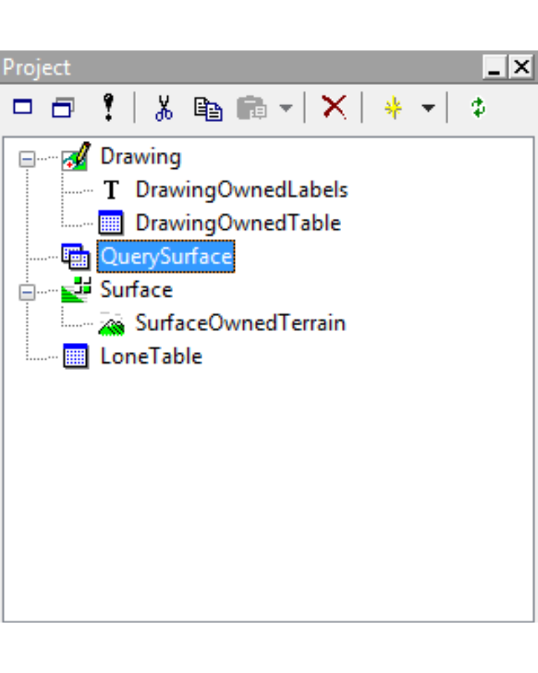

```r
library(RODBC)  ## install.packages("RODBC")
library(manifoldr) ## https://github.com/mdsumner/manifoldr
# or just source the function in the Notes below
mapfile <- "C:/temp/Components.map"
con <- odbcConnectManifold(mapfile)
print(con)  ## summary of the connection
```

If I ask what tables are available, it’s not comprehensive.

```r
sqlTables(con)
```

```
##   TABLE_CAT TABLE_SCHEM                TABLE_NAME TABLE_TYPE REMARKS
## 1      <NA>        <NA>                 LoneTable      TABLE
## 2      <NA>        <NA>         DrawingOwnedTable      TABLE
## 3      <NA>        <NA>              QuerySurface       VIEW
## 4      <NA>        <NA>          GEOMETRY_COLUMNS      TABLE
## 5      <NA>        <NA> SPATIAL_REFERENCE_SYSTEMS      TABLE
## 6      <NA>        <NA>              drawing_attr       VIEW
## 7      <NA>        <NA>        drawing_wkb_native       VIEW
## 8      <NA>        <NA>        drawing_wkb_latlon       VIEW
```

I can read from `LoneTable`, `DrawingOwnedTable`, and `QuerySurface` unsurprisingly.

```r
sqlQuery(con, "SELECT * FROM [LoneTable]")
```

```
##   Column
## 1      1
```

```r
sqlQuery(con, "SELECT [ID], [X (I)], [Latitude (I)] FROM [DrawingOwnedTable]")
```

```
##   ID X (I)  Latitude (I)
## 1  1  -196  0.0017606980
## 2  3  -338 -0.0006378039
## 3  5   -44 -0.0014013718
## 4  7   104  0.0013115403
```

```r
sqlQuery(con, "SELECT [Height (I)], [Center Y (I)] FROM [QuerySurface]")  ## SELECT TOP 1 * [From QuerySurface]
```

```
##   Height (I) Center Y (I)
## 1          0        199.5
```

But I can also read from `Drawing` and `Surface`.

```r
sqlQuery(con, "SELECT [ID] FROM [Drawing]")
```

```
##   ID
## 1  1
## 2  3
## 3  5
## 4  7
```

```r
sqlQuery(con, "SELECT TOP 2 [Easting (I)] FROM [Surface]")
```

```
##   Easting (I)
## 1           0
## 2           1
```

This is fine except that I can’t programmatically get access to the existence of `Surface` via ODBC, whereas with the Drawing, Query and stand alone Table I only need list them from `sqlTables` and query the column names in turn to get a summary of the contents in the .map file.

Thanks!

```r
odbcClose(con)
```

# Notes

```r
#' ODBC connection to Manifold map files.
#'
#' Create an ODBC connection for Manifold GIS.
#'
#' See \code{\link[RODBC]{odbcDriverConnect}}
#' @param mapfile character string, path to Manifold project *.map file
#' @param unicode logical
#' @param ansi logical
#' @param opengis logical
#' @details See the documentation for the underlying driver:
#' \url{http://www.georeference.org/doc/using_the_manifold_odbc_driver.htm}
#' @examples
#' \dontrun{
#' f <- system.file("extdata", "AreaDrawing.map", package = "manifoldr")
#' con <- odbcConnectManifold(f)
#' tab <- RODBC::sqlQuery(con, "SELECT * FROM [Drawing]")
#' ## drop [Geom (I)] and give a summary
#' summary(subset(tab, select = -`Geom (I)`))
#'
#' ## issue a spatial query
#' qtx <- "SELECT [ID], [Name], [Length (I)] AS [Perim],
#'      BranchCount([ID]) AS [nbranches] FROM [Drawing Table]"
#' sq <- RODBC::sqlQuery(con, qtx)
#' sq
#' }
#' @return RODBC object
#' @importFrom RODBC odbcDriverConnect
#' @importFrom tools toTitleCase
#' @export
odbcConnectManifold <- function (mapfile, unicode = TRUE, ansi = TRUE, opengis = TRUE)

{

  full.path <- function(filename) {

    fn <- chartr("\\", "/", filename)

    is.abs <- length(grep("^[A-Za-z]:|/", fn)) > 0

    chartr("/", "\\", if (!is.abs)

      file.path(getwd(), filename)

      else filename)

  }
  unicode <- tools::toTitleCase(tolower(format(unicode)))
  ansi <- tools::toTitleCase(tolower(format(ansi)))
  opengis <- tools::toTitleCase(tolower(format(opengis)))

  parms <- sprintf(";Unicode=%s;Ansi=%s;OpenGIS=%s;DSN=Default", unicode, ansi, opengis)

  con <- if (missing(mapfile))

    "Driver={Manifold Project Driver (*.map)};Dbq="

  else {

    fp <- full.path(mapfile)

    paste("Driver={Manifold Project Driver (*.map)};DBQ=",

          fp, ";DefaultDir=", dirname(fp), parms, ";", sep = "")

  }
RODBC::odbcDriverConnect(con)

}
```